# 52414: Lab 2

```r
print(skewness(x))
```

```
## [1] 0.008293
```

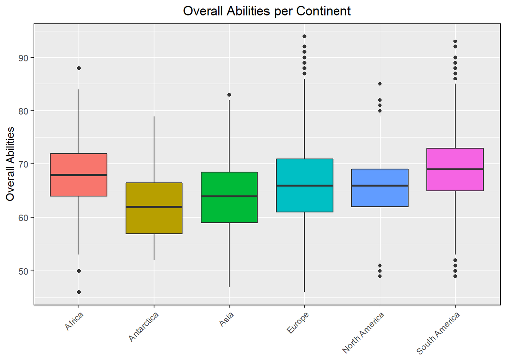

```r
DF <- data.frame(select(fifa_players, Overall,Continent))
DF$Continent <- as.character(DF$Continent)
DF$Continent[DF$Continent == "South_america"] <-"South America"
DF$Continent[DF$Continent == "North_america"] <-"North America"
DF %>%
  gather(Overall, Continent) %>%
  ggplot(aes(factor(Continent), Overall, fill = factor(Continent))) +
  geom_boxplot() +
  theme(panel.spacing = unit(0, "lines"),
        panel.border = element_rect(fill = NA),
        strip.background = element_blank(),
        axis.title.x = element_blank(),
        legend.position = "none",
        strip.placement = "outside",
        axis.text.x = element_text(angle = 45, hjust = 1)) +
  labs(title="Overall Abilities per Continent", y="Overall Abilities")+theme(plot.title = element_text(hjust = 0.5))
```

It can be seen that the average player and most of the highest players is in South America. Because also the box is the highest also the highest player concentration in addition to the highest median from the rest of the continents.

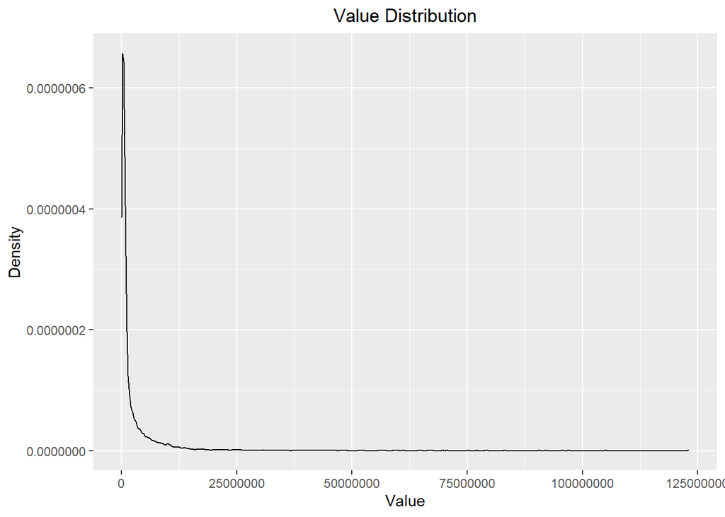

```r
#q1c
Value <- data.frame(fifa_players$Value)
Value <- Value %>% filter(fifa_players.Value != "0")
Value_Distribution <- ggplot(Value, aes(x=fifa_players.Value)) +
  geom_density() + labs(title="Value Distribution", x="Value", y="Density")+theme(plot.title = element_text(hjust = 0.5))
Value_Distribution
```

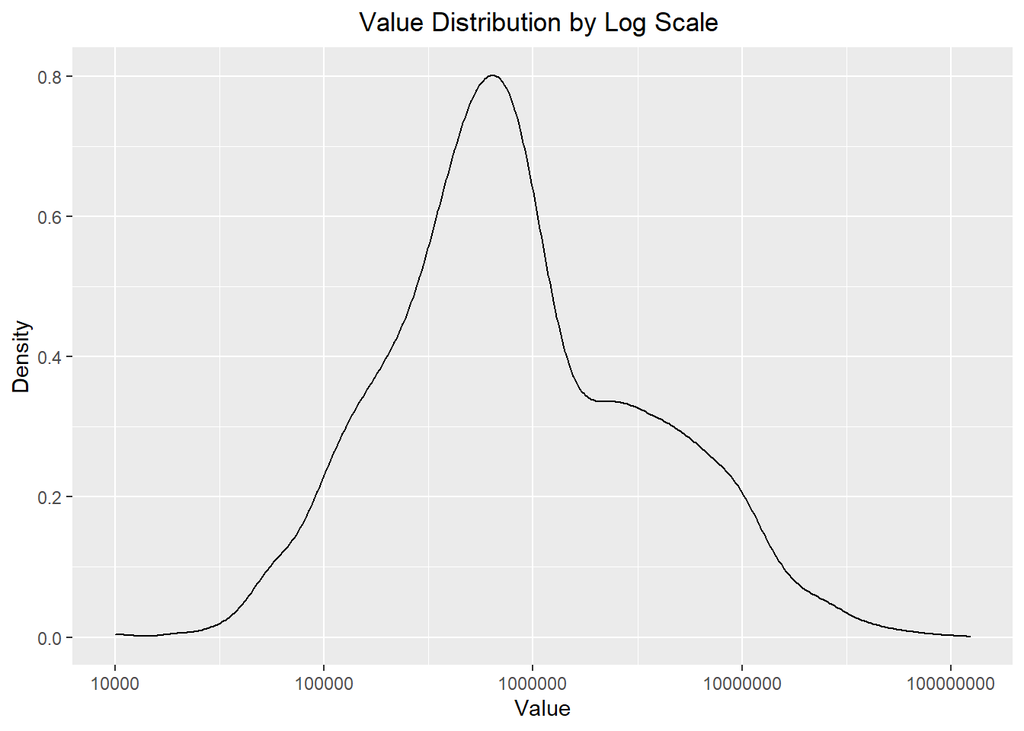

```r
Value_Distribution_Log <- ggplot(Value, aes(x=fifa_players.Value)) +
  geom_density() + scale_x_log10() + labs(title="Value Distribution by Log Scale ", x="Value", y="Density") +theme(plot.title = element_text(hjust = 0.5))
Value_Distribution_Log
```

The log visualization is better because we can see the differences between the Values more accurately. In the regular plot, there is a fat tail which makes the graph uncomfortably less informative, unlike the log plot that has a clearer scale. The log visualization is better described by a Normal Distribution as from the 100,000 Value to 10,000,000 we have Similar to the Gauss Bell.

```r
#q1d
max_value <- fifa %>% select(Name, Value) %>% arrange(desc(Value)) %>% slice(1:10)
max_value
```

```
##                 Name     Value
## 1             Neymar 123000000
## 2           L. Messi 105000000
## 3         L. Su\303¡rez  97000000
## 4  Cristiano Ronaldo  95500000
## 5     R. Lewandowski  92000000
## 6          E. Hazard  90500000
## 7       K. De Bruyne  83000000
## 8          P. Dybala  79000000
## 9           T. Kroos  79000000
## 10       G. Higua\303n  77000000
```

```r
max_overall <- fifa %>% select(Name, Overall) %>% arrange(desc(Overall)) %>% slice(1:10)
max_overall
```

```
##                 Name Overall
## 1  Cristiano Ronaldo      94
## 2           L. Messi      93
## 3             Neymar      92
## 4           M. Neuer      92
## 5         L. Su\303¡rez      92
## 6     R. Lewandowski      91
## 7          E. Hazard      90
## 8             De Gea      90
## 9        G. Higua\303n      90
## 10          T. Kroos      90
```

Most of the highest-valued players are the best players in terms of overall ability except for K. De Bruyne and P. Dybala.

```r
#q1e
olde_teams <- fifa %>% select(Club, Age) %>% group_by(Club) %>% summarise(Age = mean(Age)) %>%
              arrange(desc(Age))%>% slice(1:10)
as.data.frame(olde_teams)
```

```
##                                   Club   Age
## 1                        Brisbane Roar 31.00
## 2                       Newcastle Jets 31.00
## 3                             FC Seoul 30.75
## 4             Western Sydney Wanderers 30.75
## 5  Associa\303§\303£o Chapecoense de Futebol 30.60
## 6                      Adelaide United 30.40
## 7               Jeonbuk Hyundai Motors 30.33
## 8           Clube Atl\303©tico Paranaense 30.00
## 9    Gr\303×mio Foot-Ball Porto Alegrense 30.00
## 10                           Sydney FC 30.00
```

```r
young_teams <- fifa %>% select(Club, Age) %>% group_by(Club) %>% summarise(Age = mean(Age)) %>%
              arrange((Age))%>% slice(1:10)
as.data.frame(young_teams)
```

```
##                 Club   Age
## 1  Sevilla Atl\303©tico 19.79
## 2     FC Barcelona B 20.38
## 3   Werder Bremen II 21.46
## 4         LOSC Lille 21.63
## 5                PSV 21.88
## 6    Crewe Alexandra 21.88
## 7   FC Nordsj\303¦lland 22.00
## 8               Ajax 22.07
## 9           KRC Genk 22.08
## 10          Barnsley 22.10
```